# Regresión con Componentes Principales

```r
#Se cargan las librerías
library(tidyverse)
library(ggplot2)
library(GGally)
library(car)
library(pls)
library(tidymodels)
set.seed(1234)
```

## Conjunto de datos: Jugadores de la NBA

Se utilizará un conjunto de datos con información sobre jugadores de la NBA obtenido del sitio web Basketball Reference (https://www.basketball-reference.com/), que fue preprocesado por los docentes de EEA. Incluye información de jugadores de la NBA para la temporada 2019-2020 en base a sus estadísticas de juego durante la temporada 2018-2019. La variable respuesta es salario.

```r
# Los datos de salario son para la temporada 2019-2020
nba = read_csv("_nba_player_stats_salary_2019_2020.csv") %>%
  rename(salary = mean_salary_2019_2020) %>%
  mutate(Pos = str_remove(string = Pos, pattern = "\\-.*")) %>%
  mutate_all(~replace(., is.na(.), 0))
nba
```

| Player | Pos | Age | Tm | G | GS | MP | FG | FGA | FG% | 3P | 3PA | 3P% | 2P | 2PA | 2P% | eFG% | FT | FTA | FT% | ORB | DRB | TRB | AST | STL | BLK | TOV | PF | PTS | PER | … |
| --- | --- | --- | --- | --- | --- | --- | --- | --- | --- | --- | --- | --- | --- | --- | --- | --- | --- | --- | --- | --- | --- | --- | --- | --- | --- | --- | --- | --- | --- | --- |
| Jaylen Adams | PG | 22 | ATL | 34 | 1 | 428 | 38 | 110 | 0.345 | 25 | 74 | 0.338 | 13 | 36 | 0.361 | 0.459 | 7 | 9 | 0.778 | 11 | 49 | 60 | 65 | 14 | 5 | 28 | 45 | 108 | 7.6 | … |
| Steven Adams | C | 25 | OKC | 80 | 80 | 2669 | 481 | 809 | 0.595 | 0 | 2 | 0.000 | 481 | 807 | 0.596 | 0.595 | 146 | 292 | 0.500 | 391 | 369 | 760 | 124 | 117 | 76 | 135 | 204 | 1108 | 18.5 | … |
| Bam Adebayo | C | 21 | MIA | 82 | 28 | 1913 | 280 | 486 | 0.576 | 3 | 15 | 0.200 | 277 | 471 | 0.588 | 0.579 | 166 | 226 | 0.735 | 165 | 432 | 597 | 184 | 71 | 65 | 121 | 203 | 729 | 17.9 | … |
| LaMarcus Aldridge | C | 33 | SAS | 81 | 81 | 2687 | 684 | 1319 | 0.519 | 10 | 42 | 0.238 | 674 | 1277 | 0.528 | 0.522 | 349 | 412 | 0.847 | 251 | 493 | 744 | 194 | 43 | 107 | 144 | 179 | 1727 | 22.9 | … |
| Grayson Allen | SG | 23 | UTA | 38 | 2 | 416 | 67 | 178 | 0.376 | 32 | 99 | 0.323 | 35 | 79 | 0.443 | 0.466 | 45 | 60 | 0.750 | 3 | 20 | 23 | 25 | 6 | 6 | 33 | 47 | 211 | 7.5 | … |
| Jarrett Allen | C | 20 | BRK | 80 | 80 | 2096 | 335 | 568 | 0.590 | 6 | 45 | 0.133 | 329 | 523 | 0.629 | 0.595 | 197 | 278 | 0.709 | 191 | 481 | 672 | 110 | 43 | 120 | 103 | 184 | 873 | 18.5 | … |
| Al-Farouq Aminu | PF | 28 | POR | 81 | 81 | 2292 | 257 | 593 | 0.433 | 96 | 280 | 0.343 | 161 | 313 | 0.514 | 0.514 | 150 | 173 | 0.867 | 112 | 498 | 610 | 104 | 68 | 33 | 72 | 143 | 760 | 13.2 | … |
| Justin Anderson | SF | 25 | ATL | 48 | 4 | 463 | 64 | 157 | 0.408 | 24 | 77 | 0.312 | 40 | 80 | 0.500 | 0.484 | 26 | 35 | 0.743 | 24 | 60 | 84 | 23 | 22 | 13 | 23 | 48 | 178 | 11.2 | … |
| Kyle Anderson | SF | 25 | MEM | 43 | 40 | 1281 | 150 | 276 | 0.543 | 9 | 34 | 0.265 | 141 | 242 | 0.583 | 0.560 | 37 | 64 | 0.578 | 48 | 203 | 251 | 128 | 54 | 37 | 58 | 112 | 346 | 12.8 | … |
| Ryan Anderson | PF | 30 | TOT | 25 | 8 | 322 | 21 | 69 | 0.304 | 9 | 40 | 0.225 | 12 | 29 | 0.414 | 0.370 | 12 | 16 | 0.750 | 18 | 36 | 54 | 19 | 4 | 1 | 14 | 25 | 63 | 4.6 | … |

[output cut: 385 more lines]

```r
#Se conservan solo las variables numéricas
nba_num<-nba%>%select_if(is.numeric)
```

## Análisis exploratorio

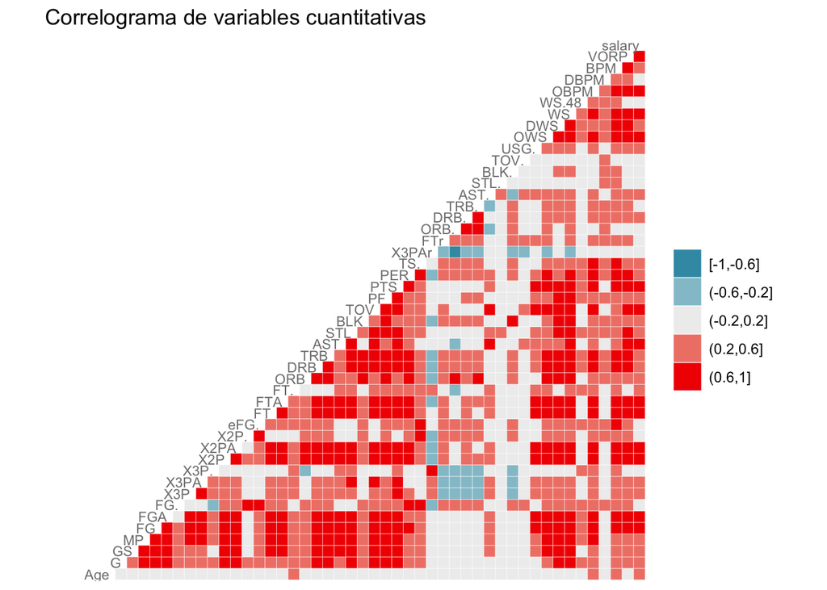

```r
#Correlación de Pearson
nba_num %>%
  ggcorr(., layout.exp = 5, hjust = 1, size = 3, nbreaks = 5, color = "grey50") +
  labs(title='Correlograma de variables cuantitativas')
```

Un gran número de variables presenta una correlación positiva por arriba en el rango [0.6,1]

```r
#Se genera un nuevo dataframe sin la variable respuesta "salary"
nba_x<-nba_num%>%select(-c(salary))
```

## Ajuste de Modelo Lineal

```r
#Estandarización
nba_xs<-as.data.frame(scale(nba_x))
nba_y<-nba_num%>%select(c(salary))
nba_ys<-as.data.frame(scale(nba_y))
nba_xs_y<-data.frame(nba_y,nba_xs)
#Eliminación de NA
nba_xs_y<-nba_xs_y%>%select(-c(X2P,X2PA,TRB,PTS))
```

```r
#Modelo Lineal
ml<-lm(salary~.,data=nba_xs_y)
tidy_ml <- tidy(ml, conf.int = TRUE)
tidy_ml
```

| term | estimate | std.error | statistic | p.value | conf.low | conf.high |
| --- | --- | --- | --- | --- | --- | --- |
| (Intercept) | 8491100.9 | 292528.2 | 29.0266073 | 2.030433e-95 | 7915778.0 | 9066423.7 |
| Age | 1725873.6 | 331543.2 | 5.2055775 | 3.294677e-07 | 1073819.0 | 2377928.3 |
| G | -2966106.1 | 899021.1 | -3.2992619 | 1.068442e-03 | -4734234.5 | -1197977.7 |
| GS | 470885.6 | 692807.1 | 0.6796778 | 4.971552e-01 | -891676.3 | 1833447.5 |
| MP | -2436743.8 | 2679974.6 | -0.9092414 | 3.638448e-01 | -7707520.1 | 2834032.4 |
| FG | -3339800.2 | 10856740.9 | -0.3076246 | 7.585500e-01 | -24692037.2 | 18012436.8 |
| FGA | 9690405.3 | 11593863.1 | 0.8358220 | 4.038221e-01 | -13111549.4 | 32492360.0 |
| FG. | -1523812.1 | 5867304.6 | -0.2597125 | 7.952374e-01 | -13063193.8 | 10015569.7 |
| X3P | 877194.3 | 3739559.4 | 0.2345716 | 8.146777e-01 | -6477495.3 | 8231883.9 |
| X3PA | -998058.4 | 3868677.3 | -0.2579844 | 7.965697e-01 | -8606687.5 | 6610570.7 |

[output cut: 33 more lines]

```r
glance(ml)
```

| r.squared | adj.r.squared | sigma | statistic | p.value | df | logLik | AIC | BIC | deviance | df.residual | nobs |
| --- | --- | --- | --- | --- | --- | --- | --- | --- | --- | --- | --- |
| 0.6621195 | 0.6218042 | 5813883 | 16.42353 | 3.388826e-60 | 42 | -6690.143 | 13468.29 | 13643.36 | 1.189803e+16 | 352 | 395 |

Al ajustar el modelo, se observa que, a pesar de tener un coeficiente de determinación de 0.66, la mayoría de las variables resultan no significativas. Además, el coeficiente de algunas variables, por ejemplo G, tiene signo negativo, contrario a lo que se espera del efecto del aumento de la cantidad de partidos sobre el salario de un jugador.

```r
#Diagnóstico formal de multicolinealidad: VIF
VIF<-as.data.frame(vif(ml))
print(VIF)
```

```
##           vif(ml)
## Age      1.281279
## G        9.421140
## GS       5.594849
## MP      83.719191
## FG    1373.923730
## FGA   1566.823291
## FG.    401.273931
## X3P    163.006365
## X3PA   174.457117
## X3P.     3.702180
## X2P.    10.256186
## eFG.   380.895804
## FT     361.397921
## FTA    211.394745
## FT.      4.702789
## ORB     31.292955
## DRB     26.947053
## AST     76.137774
## STL     16.716841
## BLK      9.257956
## TOV    108.905895
## PF      10.875857
## PER     97.530565
## TS.    149.688693
## X3PAr   77.961375
## FTr      7.377490
## ORB.   327.494629
## DRB.   827.592894
## TRB.  1785.020144
## AST.    11.287039
## STL.     5.761020
## BLK.     6.989442
## TOV.     3.903875
## USG.    14.701496
## OWS   1718.477474
## DWS    538.037753
## WS    3418.511162
## WS.48    3.075627
## OBPM  3530.534366
## DBPM   827.667848
## BPM   5130.125141
## VORP    56.064220
```

Se observa que la mayoría de las variables presentan un VIF alto (cercano o mayor a 10), indicando la existencia de multicolinealidad.

```r
#Se ajusta un modelo lineal solo con las variables significativas
ml_3<-lm(salary~Age+G+TOV.,data=nba_xs_y)
tidy_ml_3 <- tidy(ml_3, conf.int = TRUE)
tidy_ml_3
```

| term | estimate | std.error | statistic | p.value | conf.low | conf.high |
| --- | --- | --- | --- | --- | --- | --- |
| (Intercept) | 8491100.9 | 431996.6 | 19.6554797 | 2.585936e-60 | 7641774.0 | 9340428 |
| Age | 2434052.8 | 435315.4 | 5.5914695 | 4.233885e-08 | 1578201.1 | 3289904 |
| G | 2906582.0 | 436788.4 | 6.6544399 | 9.628293e-11 | 2047834.3 | 3765330 |
| TOV. | 320629.6 | 434022.0 | 0.7387405 | 4.605078e-01 | -532679.2 | 1173938 |

```r
glance(ml_3)
```

| r.squared | adj.r.squared | sigma | statistic | p.value | df | logLik | AIC | BIC | deviance | df.residual | nobs |
| --- | --- | --- | --- | --- | --- | --- | --- | --- | --- | --- | --- |
| 0.1814927 | 0.1752126 | 8585763 | 28.89962 | 6.746809e-17 | 3 | -6864.889 | 13739.78 | 13759.67 | 2.882269e+16 | 391 | 395 |

El modelo tiene un coeficiente de determinación bajo (0.18)

## Regresión con componentes principales

```r
ml_pcr<-pcr(salary~.,data=nba_xs_y,scale=TRUE,validation="CV")
summary(ml_pcr)
```

```
## Data:    X dimension: 395 42
##  Y dimension: 395 1
## Fit method: svdpc
## Number of components considered: 42
##
## VALIDATION: RMSEP
## Cross-validated using 10 random segments.
##        (Intercept)  1 comps  2 comps  3 comps  4 comps  5 comps  6 comps
## CV         9465822  6860887  6694046  6540325  6452239  6460590  6238604
## adjCV      9465822  6856642  6689407  6534240  6443973  6453667  6229112
##        7 comps  8 comps  9 comps  10 comps  11 comps  12 comps  13 comps
## CV     6247149  6068912  6074284   6090445   6110449   6090824   6107744
## adjCV  6245386  6057895  6064472   6081164   6101297   6080348   6095867
##        14 comps  15 comps  16 comps  17 comps  18 comps  19 comps  20 comps
## CV      6111444   6051563   5988428   6006591   5979964   5977350   5983315
## adjCV   6102102   6052540   5974944   5993893   5958246   5961242   5968214
##        21 comps  22 comps  23 comps  24 comps  25 comps  26 comps  27 comps
## CV      5963829   5991979   5982273   5991889   6013723   6010778   6035466
## adjCV   5944101   5972904   5962967   5971254   5993211   5989393   6013290
##        28 comps  29 comps  30 comps  31 comps  32 comps  33 comps  34 comps
## CV      6054767   6039023   6068171   6080479   6038778   6065496   6114941
## adjCV   6037473   6013830   6041574   6053199   6011710   6036505   6082953
##        35 comps  36 comps  37 comps  38 comps  39 comps  40 comps  41 comps
## CV      6119129   6147904   6166729   6183768   6230490   6235891   6243843
## adjCV   6086588   6113032   6130791   6146838   6190521   6195613   6202698
##        42 comps
## CV      6258958
## adjCV   6216714
##
## TRAINING: % variance explained
##         1 comps  2 comps  3 comps  4 comps  5 comps  6 comps  7 comps  8 comps
## X         40.67    57.93    65.52    71.01    75.93    79.57    82.23    84.63
## salary    48.24    50.85    53.49    55.22    55.26    58.35    58.42    60.66
##         9 comps  10 comps  11 comps  12 comps  13 comps  14 comps  15 comps
## X         86.65     88.40     90.10     91.54     92.81     93.86     94.78
## salary    60.67     60.67     60.68     61.12     61.25     61.27     61.97
##         16 comps  17 comps  18 comps  19 comps  20 comps  21 comps  22 comps
## X          95.63     96.32     96.89     97.41     97.82     98.19     98.52
## salary     62.87     62.98     63.83     63.90     63.96     64.42     64.47
##         23 comps  24 comps  25 comps  26 comps  27 comps  28 comps  29 comps
## X          98.82     99.04     99.23     99.41     99.55     99.65     99.75
## salary     64.55     64.62     64.69     64.74     64.74     64.75     65.09
##         30 comps  31 comps  32 comps  33 comps  34 comps  35 comps  36 comps
## X          99.83     99.88     99.92     99.95     99.97     99.98     99.99
## salary     65.17     65.17     65.63     65.75     65.76     65.90     65.97
##         37 comps  38 comps  39 comps  40 comps  41 comps  42 comps
## X          99.99    100.00    100.00    100.00    100.00    100.00
## salary     65.98     65.98     66.07     66.07     66.14     66.21
```

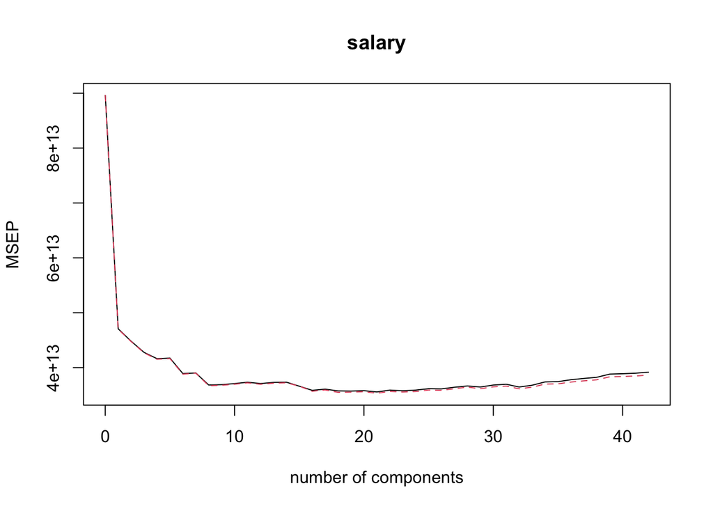

```r
validationplot(ml_pcr,val.type="MSEP")
```

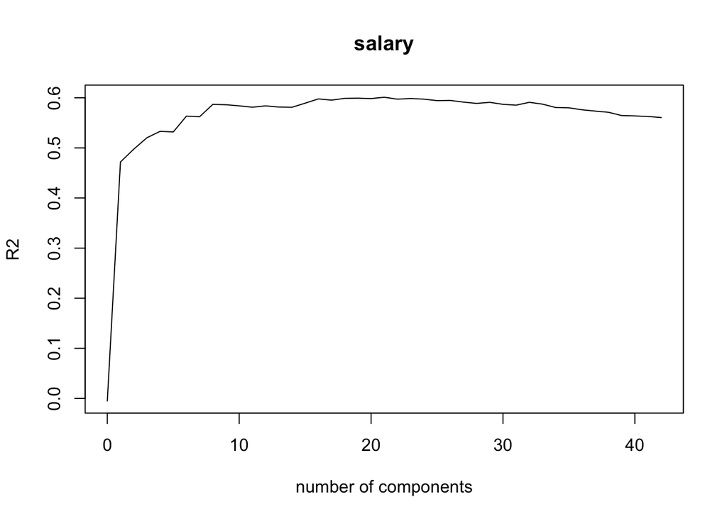

```r
validationplot(ml_pcr, val.type = "R2")
```

```r
coef_pcr<-data.frame(ml_pcr$coefficients)
```

```r
ml_pcr_18 <-pcr(salary~.,data=nba_xs_y,scale=TRUE,validation="CV",ncomp=18)
summary(ml_pcr_18)
```

```
## Data:    X dimension: 395 42
##  Y dimension: 395 1
## Fit method: svdpc
## Number of components considered: 18
##
## VALIDATION: RMSEP
## Cross-validated using 10 random segments.
##        (Intercept)  1 comps  2 comps  3 comps  4 comps  5 comps  6 comps
## CV         9465822  6835401  6717413  6554697  6477328  6491296  6259152
## adjCV      9465822  6832719  6712374  6548131  6466969  6482976  6250689
##        7 comps  8 comps  9 comps  10 comps  11 comps  12 comps  13 comps
## CV     6256510  6101909  6123051   6134309   6147555   6145661   6154494
## adjCV  6254304  6087992  6110034   6122195   6135280   6134822   6140631
##        14 comps  15 comps  16 comps  17 comps  18 comps
## CV      6154542   6097105   6080485   6096280   6054839
## adjCV   6142021   6085686   6062415   6078374   6031568
##
## TRAINING: % variance explained
##         1 comps  2 comps  3 comps  4 comps  5 comps  6 comps  7 comps  8 comps
## X         40.67    57.93    65.52    71.01    75.93    79.57    82.23    84.63
## salary    48.24    50.85    53.49    55.22    55.26    58.35    58.42    60.66
##         9 comps  10 comps  11 comps  12 comps  13 comps  14 comps  15 comps
## X         86.65     88.40     90.10     91.54     92.81     93.86     94.78
## salary    60.67     60.67     60.68     61.12     61.25     61.27     61.97
##         16 comps  17 comps  18 comps
## X          95.63     96.32     96.89
## salary     62.87     62.98     63.83
```

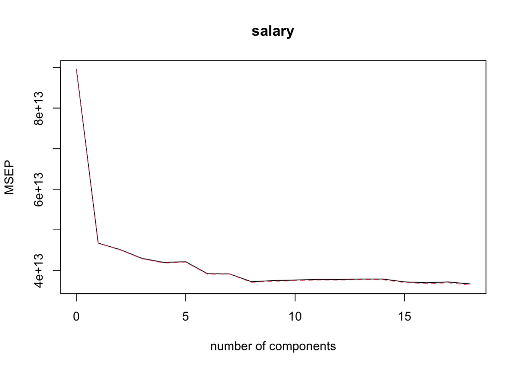

```r
validationplot(ml_pcr_18,val.type="MSEP")
```

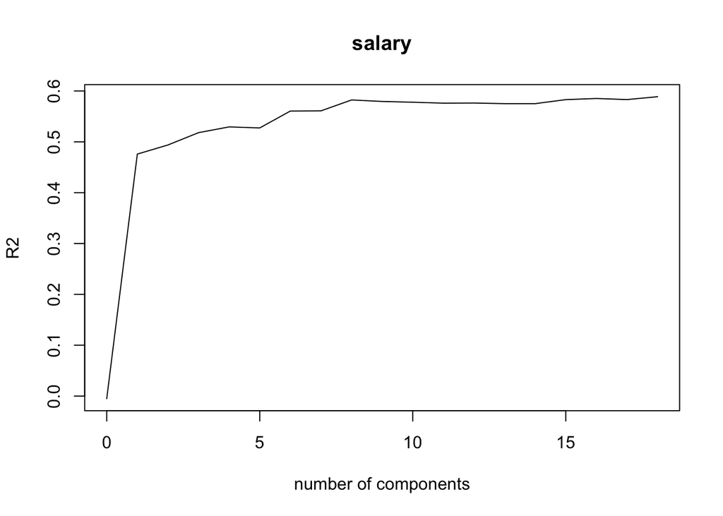

```r
validationplot(ml_pcr_18, val.type = "R2")
```

El modelo ajustado por regresión por componentes principales, con 18 PC, tiene un coeficiente de determinación de ~0.58

A continuación, tomamos las componentes principales para ajustar un modelo lineal

```r
nba.pca1<-prcomp(nba_xs_y[,2:43],scale=TRUE)
summary(nba.pca1)$importance
```

```
##                             PC1      PC2      PC3      PC4      PC5      PC6
## Standard deviation     4.132938 2.692788 1.784662 1.518831 1.438113 1.235119
## Proportion of Variance 0.406690 0.172650 0.075830 0.054920 0.049240 0.036320
## Cumulative Proportion  0.406690 0.579340 0.655170 0.710100 0.759340 0.795660
##                             PC7      PC8       PC9      PC10      PC11
## Standard deviation     1.057565 1.004165 0.9209031 0.8567931 0.8460982
## Proportion of Variance 0.026630 0.024010 0.0201900 0.0174800 0.0170400
## Cumulative Proportion  0.822290 0.846300 0.8664900 0.8839700 0.9010200
##                             PC12      PC13      PC14      PC15      PC16
## Standard deviation     0.7763704 0.7324463 0.6625553 0.6215772 0.5982489
## Proportion of Variance 0.0143500 0.0127700 0.0104500 0.0092000 0.0085200
## Cumulative Proportion  0.9153700 0.9281400 0.9385900 0.9477900 0.9563100
##                             PC17      PC18      PC19      PC20      PC21
## Standard deviation     0.5361896 0.4894538 0.4703834 0.4134979 0.3952823
## Proportion of Variance 0.0068500 0.0057000 0.0052700 0.0040700 0.0037200
## Cumulative Proportion  0.9631600 0.9688600 0.9741300 0.9782000 0.9819200
##                             PC22      PC23     PC24      PC25      PC26
## Standard deviation     0.3729073 0.3558631 0.301244 0.2829544 0.2706631
## Proportion of Variance 0.0033100 0.0030200 0.002160 0.0019100 0.0017400
## Cumulative Proportion  0.9852300 0.9882500 0.990410 0.9923100 0.9940600
##                             PC27      PC28     PC29      PC30      PC31
## Standard deviation     0.2434061 0.2082429 0.201481 0.1890321 0.1478282
## Proportion of Variance 0.0014100 0.0010300 0.000970 0.0008500 0.0005200
## Cumulative Proportion  0.9954700 0.9965000 0.997470 0.9983200 0.9988400
##                             PC32      PC33       PC34       PC35      PC36
## Standard deviation     0.1251946 0.1072848 0.08380097 0.07448418 0.0640143
## Proportion of Variance 0.0003700 0.0002700 0.00017000 0.00013000 0.0001000
## Cumulative Proportion  0.9992100 0.9994900 0.99965000 0.99979000 0.9998800
##                              PC37       PC38       PC39       PC40       PC41
## Standard deviation     0.05232536 0.03461772 0.02040215 0.01614697 0.01335656
## Proportion of Variance 0.00007000 0.00003000 0.00001000 0.00001000 0.00000000
## Cumulative Proportion  0.99995000 0.99998000 0.99999000 0.99999000 1.00000000
##                              PC42
## Standard deviation     0.01021935
## Proportion of Variance 0.00000000
## Cumulative Proportion  1.00000000
```

```r
pcss<-as.data.frame(nba.pca1$x)
pcs_y<-data.frame(nba_y,pcss)
```

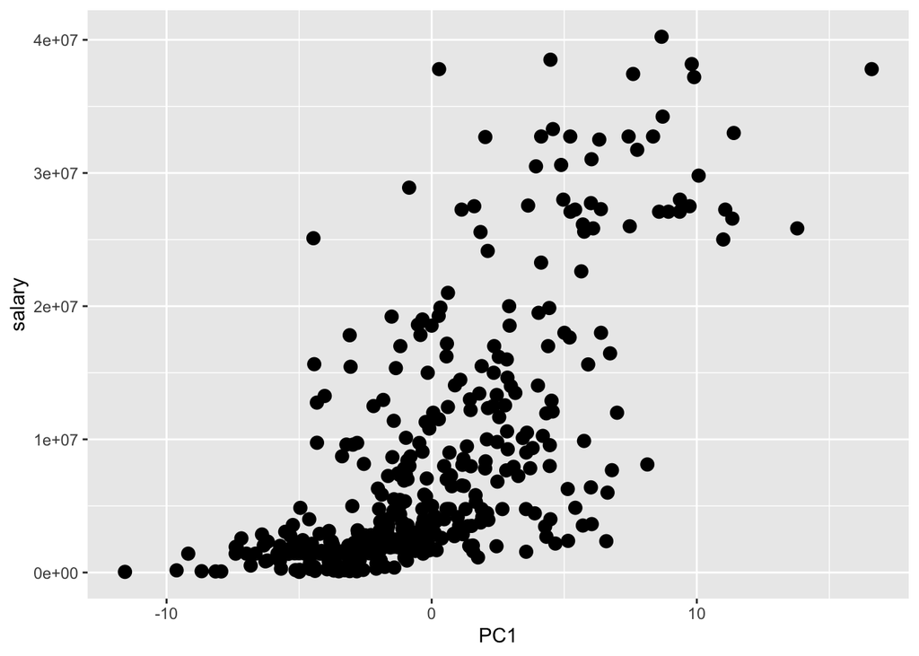

```r
#Datos proyectadoos en PC1
ggplot(pcs_y, aes(x=PC1, y=salary)) +
  geom_point(size=3) +
  theme(legend.position="none")
```

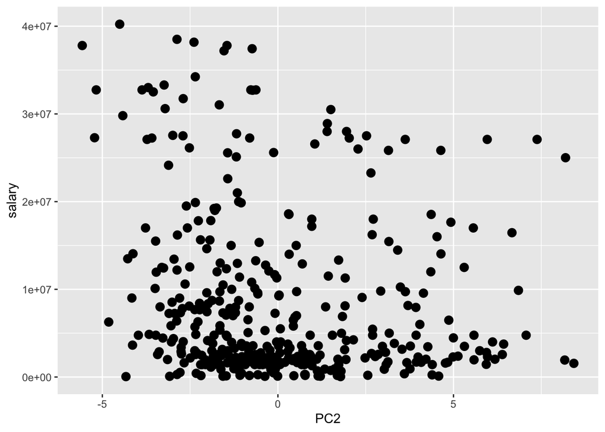

```r
#Datos proyectados en PC2
ggplot(pcs_y, aes(x=PC2, y=salary)) +
  geom_point(size=3) +
  theme(legend.position="none")
```

```r
#Se ajusta un modelo lineal con las primeras 18 PC
ml_PC18<-lm(salary~PC1+PC2+PC3+PC4+PC5+PC6+PC7+PC8+PC9+PC10+PC11+PC12+PC13+PC14+PC15+PC16+PC17+PC18,data=pcs_y)
summary(ml_PC18)
```

```
##
## Call:
## lm(formula = salary ~ PC1 + PC2 + PC3 + PC4 + PC5 + PC6 + PC7 +
##     PC8 + PC9 + PC10 + PC11 + PC12 + PC13 + PC14 + PC15 + PC16 +
##     PC17 + PC18, data = pcs_y)
##
## Residuals:
##       Min        1Q    Median        3Q       Max
## -17261862  -3286322   -262397   2538656  22855096
##
## Coefficients:
##             Estimate Std. Error t value Pr(>|t|)
## (Intercept)  8491101     292848  28.995  < 2e-16 ***
## PC1          1588757      70947  22.394  < 2e-16 ***
## PC2          -567386     108891  -5.211 3.11e-07 ***
## PC3           860358     164300   5.237 2.73e-07 ***
## PC4           818742     193056   4.241 2.81e-05 ***
## PC5          -130406     203892  -0.640  0.52283
## PC6          1344944     237402   5.665 2.92e-08 ***
## PC7          -237645     277259  -0.857  0.39192
## PC8          1410421     292004   4.830 1.99e-06 ***
## PC9            68501     318405   0.215  0.82978
## PC10           42799     342229   0.125  0.90054
## PC11          118448     346555   0.342  0.73270
## PC12          805217     377680   2.132  0.03365 *
## PC13         -463436     400330  -1.158  0.24775
## PC14          205808     442559   0.465  0.64217
## PC15        -1272767     471735  -2.698  0.00729 **
## PC16        -1500800     490130  -3.062  0.00236 **
## PC17          580223     546858   1.061  0.28937
## PC18        -1782359     599076  -2.975  0.00312 **
## ---
## Signif. codes:  0 '***' 0.001 '**' 0.01 '*' 0.05 '.' 0.1 ' ' 1
##
## Residual standard error: 5820000 on 376 degrees of freedom
## Multiple R-squared:  0.6383, Adjusted R-squared:  0.621
## F-statistic: 36.86 on 18 and 376 DF,  p-value: < 2.2e-16
```

```r
VIF2<-as.data.frame(vif(ml_PC18))
print(VIF2)
```

```
##      vif(ml_PC18)
## PC1             1
## PC2             1
## PC3             1
## PC4             1
## PC5             1
## PC6             1
## PC7             1
## PC8             1
## PC9             1
## PC10            1
## PC11            1
## PC12            1
## PC13            1
## PC14            1
## PC15            1
## PC16            1
## PC17            1
## PC18            1
```